# bottleneck - html

[figure not shown]

**Sommaire COPIL**

- Import des librairies

I. Exploration, nettoyage et rapprochement des fichiers

- 1.1 Fichier ERP
- 1.2 Fichier WEB
- 1.3 Fichier LIAISON
- 1.4 Rapprochement des fichiers
- II. Chiffre d'affaire : analyses
- 2.1 Chiffre d'affaire par produit
- 2.2 Chiffre d'affaire réalisé en ligne
- III. Prix : identification des outliers
- 3.1 Indentification
- 3.2 Représentation graphique
- IV. Conclusion

**Import des librairies**

```python
import pandas as pd
import numpy as np
import matplotlib.pyplot as plt
import matplotlib.cbook as cbk
```

**I . Exploration, nettoyage et rapprochement des fichiers**

**1.1 Fichier ERP**

```python
erp = pd.read_excel("erp.xls")
erp.head()
```

|  | product_id | onsale_web | price | stock_quantity | stock_status |
| --- | --- | --- | --- | --- | --- |
| 0 | 3847 | 1 | 24.2 | 0 | outofstock |
| 1 | 3849 | 1 | 34.3 | 0 | outofstock |
| 2 | 3850 | 1 | 20.8 | 0 | outofstock |
| 3 | 4032 | 1 | 14.1 | 0 | outofstock |
| 4 | 4039 | 1 | 46.0 | 0 | outofstock |

### Dimensions du dataframe ERP

```python
erp.shape
```

```
(825, 5)
```

### Type de données du dataframe ERP

```python
erp.dtypes
```

```
product_id          int64
onsale_web          int64
price             float64
stock_quantity      int64
stock_status       object
dtype: object
```

### Conversion du type de données product_id et onsaleweb

```python
#convertir id en object
erp["product_id"] = erp["product_id"].astype("object")
erp["onsale_web"] = erp["onsale_web"].astype("object")
erp.dtypes
```

```
product_id         object
onsale_web         object
price             float64
stock_quantity      int64
stock_status       object
dtype: object
```

### Etude de la clé product_ID et autres variables

```python
erp.describe(include = "all")
#825 id uniques sur 825 lignes
```

|  | product_id | onsale_web | price | stock_quantity | stock_status |
| --- | --- | --- | --- | --- | --- |
| count | 825.0 | 825.0 | 825.000000 | 825.000000 | 825 |
| unique | 825.0 | 2.0 | NaN | NaN | 2 |
| top | 4096.0 | 1.0 | NaN | NaN | instock |
| freq | 1.0 | 717.0 | NaN | NaN | 638 |
| mean | NaN | NaN | 32.415636 | 26.496970 | NaN |
| std | NaN | NaN | 26.795849 | 45.892422 | NaN |
| min | NaN | NaN | 5.200000 | 0.000000 | NaN |
| 25% | NaN | NaN | 14.600000 | 1.000000 | NaN |
| 50% | NaN | NaN | 24.400000 | 11.000000 | NaN |
| 75% | NaN | NaN | 42.000000 | 34.000000 | NaN |
| max | NaN | NaN | 225.000000 | 578.000000 | NaN |

### Nombre de valeurs nulles

```python
erp.info()
```

```
<class 'pandas.core.frame.DataFrame'>
RangeIndex: 825 entries, 0 to 824
Data columns (total 5 columns):
 #   Column          Non-Null Count  Dtype
---  ------          --------------  -----
 0   product_id      825 non-null    object
 1   onsale_web      825 non-null    object
 2   price           825 non-null    float64
 3   stock_quantity  825 non-null    int64
 4   stock_status    825 non-null    object
dtypes: float64(1), int64(1), object(3)
memory usage: 32.4+ KB
```

### Nombre de doublons du dataframe ERP

```python
doublons_erp = erp.duplicated()
doublons_erp.value_counts()
```

```
False    825
dtype: int64
```

### Etude du nombre de produits vendus en ligne d'apres le dataframe ERP

```python
erp["onsale_web"].value_counts()
#717 articles vendus sur le web d'après l'ERP ==> 717 sku ?
```

```
1    717
0    108
Name: onsale_web, dtype: int64
```

### Etude du stock dataframe ERP

```python
is_in_stock = erp["stock_quantity"]>0
is_in_stock.value_counts()
```

```
True     637
False    188
Name: stock_quantity, dtype: int64
```

```python
erp["stock_status"].value_counts()
```

```
instock       638
outofstock    187
Name: stock_status, dtype: int64
```

```python
# une erreur concernant le statut du stock
erp[(erp["stock_quantity"] == 0 )&(erp["stock_status"] == "instock")]
```

|  | product_id | onsale_web | price | stock_quantity | stock_status |
| --- | --- | --- | --- | --- | --- |
| 443 | 4954 | 1 | 25.0 | 0 | instock |

**1.2 Fichier WEB**

```python
web = pd.read_excel("web.xls")
web.head()
```

|  | sku | virtual | downloadable | rating_count | average_rating | total_sales | tax_status | tax_class | post_author | post_date | ... | post_name | post_modified | post_modified_gmt | post_content_filtered | post_parent | guid | menu_order | post_type | post_mime_type | comment_count |
| --- | --- | --- | --- | --- | --- | --- | --- | --- | --- | --- | --- | --- | --- | --- | --- | --- | --- | --- | --- | --- | --- |
| 0 | bon-cadeau-25-euros | 0 | 0 | 0 | 0.0 | 10.0 | taxable | NaN | 1.0 | 2018-06-01 13:53:46 | ... | bon-cadeau-de-25-euros | 2018-06-01 14:13:57 | 2018-06-01 12:13:57 | NaN | 0.0 | https://www.bottle-neck.fr/?post_type=product&... | 0.0 | product | NaN | 0.0 |
| 1 | 15298 | 0 | 0 | 0 | 0.0 | 6.0 | taxable | NaN | 2.0 | 2018-02-08 12:58:52 | ... | pierre-jean-villa-saint-joseph-preface-2018 | 2019-12-30 09:30:29 | 2019-12-30 08:30:29 | NaN | 0.0 | https://www.bottle-neck.fr/?post_type=product&... | 0.0 | product | NaN | 0.0 |
| 2 | 15296 | 0 | 0 | 0 | 0.0 | 0.0 | taxable | NaN | 2.0 | 2018-02-08 13:49:41 | ... | pierre-jean-villa-saint-joseph-tilde-2017 | 2019-12-21 09:00:17 | 2019-12-21 08:00:17 | NaN | 0.0 | https://www.bottle-neck.fr/?post_type=product&... | 0.0 | product | NaN | 0.0 |
| 3 | 15300 | 0 | 0 | 0 | 0.0 | 0.0 | taxable | NaN | 2.0 | 2018-02-08 14:08:36 | ... | pierre-jean-villa-croze-hermitage-accroche-coe... | 2020-06-26 18:15:03 | 2020-06-26 16:15:03 | NaN | 0.0 | https://www.bottle-neck.fr/?post_type=product&... | 0.0 | product | NaN | 0.0 |
| 4 | 19814 | 0 | 0 | 0 | 0.0 | 3.0 | taxable | NaN | 2.0 | 2018-02-09 14:01:05 | ... | pierre-jean-villa-igp-gamine-2018 | 2020-01-04 16:36:01 | 2020-01-04 15:36:01 | NaN | 0.0 | https://www.bottle-neck.fr/?post_type=product&... | 0.0 | product | NaN | 0.0 |

5 rows × 28 columns

### Dimensions du dataframe WEB

```python
web.shape
```

```
(1513, 28)
```

### Type de données du dataframe WEB

```python
web.dtypes
```

```
sku                              object
virtual                           int64
downloadable                      int64
rating_count                      int64
average_rating                  float64
total_sales                     float64
tax_status                       object
tax_class                       float64
post_author                     float64
post_date                datetime64[ns]
post_date_gmt            datetime64[ns]
post_content                    float64
post_title                       object
post_excerpt                     object
post_status                      object
comment_status                   object
ping_status                      object
post_password                   float64
post_name                        object
post_modified            datetime64[ns]
post_modified_gmt        datetime64[ns]
post_content_filtered           float64
post_parent                     float64
guid                             object
menu_order                      float64
post_type                        object
post_mime_type                   object
comment_count                   float64
dtype: object
```

### Etude de la clé sku et autres variables

```python
web.describe(include = "all", datetime_is_numeric=True)
#714 sku uniques (vs 717 produits en ligne d'après l'ERP et 1428 sku dans le dataframe WEB)
```

|  | sku | virtual | downloadable | rating_count | average_rating | total_sales | tax_status | tax_class | post_author | post_date | ... | post_name | post_modified | post_modified_gmt | post_content_filtered | post_parent | guid | menu_order | post_type | post_mime_type | comment_count |
| --- | --- | --- | --- | --- | --- | --- | --- | --- | --- | --- | --- | --- | --- | --- | --- | --- | --- | --- | --- | --- | --- |
| count | 1428.0 | 1513.0 | 1513.0 | 1513.0 | 1430.0 | 1430.000000 | 716 | 0.0 | 1430.000000 | 1430 | ... | 1430 | 1430 | 1430 | 0.0 | 1430.0 | 1430 | 1430.0 | 1430 | 714 | 1430.0 |
| unique | 714.0 | NaN | NaN | NaN | NaN | NaN | 1 | NaN | NaN | NaN | ... | 716 | NaN | NaN | NaN | NaN | 1430 | NaN | 2 | 1 | NaN |
| top | 15360.0 | NaN | NaN | NaN | NaN | NaN | taxable | NaN | NaN | NaN | ... | decelle-villa-nuits-st-georges-rouge-2016 | NaN | NaN | NaN | NaN | https://www.bottle-neck.fr/?post_type=product&... | NaN | product | image/jpeg | NaN |
| freq | 2.0 | NaN | NaN | NaN | NaN | NaN | 716 | NaN | NaN | NaN | ... | 2 | NaN | NaN | NaN | NaN | 1 | NaN | 716 | 714 | NaN |
| mean | NaN | 0.0 | 0.0 | 0.0 | 0.0 | 4.006993 | NaN | NaN | 1.998601 | 2018-08-22 03:22:17.090908928 | ... | NaN | 2020-06-20 13:59:29.781818368 | 2020-06-20 12:06:02.509090816 | NaN | 0.0 | NaN | 0.0 | NaN | NaN | 0.0 |
| min | NaN | 0.0 | 0.0 | 0.0 | 0.0 | 0.000000 | NaN | NaN | 1.000000 | 2018-02-08 12:58:52 | ... | NaN | 2018-02-20 15:19:23 | 2018-02-20 14:19:23 | NaN | 0.0 | NaN | 0.0 | NaN | NaN | 0.0 |
| 25% | NaN | 0.0 | 0.0 | 0.0 | 0.0 | 0.000000 | NaN | NaN | 2.000000 | 2018-02-27 20:01:12.500000 | ... | NaN | 2020-06-18 10:45:05.249999872 | 2020-06-18 08:45:05.249999872 | NaN | 0.0 | NaN | 0.0 | NaN | NaN | 0.0 |
| 50% | NaN | 0.0 | 0.0 | 0.0 | 0.0 | 1.000000 | NaN | NaN | 2.000000 | 2018-04-19 14:56:05 | ... | NaN | 2020-08-04 09:30:06 | 2020-08-04 07:30:06 | NaN | 0.0 | NaN | 0.0 | NaN | NaN | 0.0 |
| 75% | NaN | 0.0 | 0.0 | 0.0 | 0.0 | 4.000000 | NaN | NaN | 2.000000 | 2019-01-31 14:35:47 | ... | NaN | 2020-08-25 10:32:32 | 2020-08-25 08:32:32 | NaN | 0.0 | NaN | 0.0 | NaN | NaN | 0.0 |
| max | NaN | 0.0 | 0.0 | 0.0 | 0.0 | 96.000000 | NaN | NaN | 2.000000 | 2020-07-20 11:00:00 | ... | NaN | 2020-08-27 18:55:03 | 2020-08-27 16:55:03 | NaN | 0.0 | NaN | 0.0 | NaN | NaN | 0.0 |
| std | NaN | 0.0 | 0.0 | 0.0 | 0.0 | 8.510559 | NaN | NaN | 0.037385 | NaN | ... | NaN | NaN | NaN | NaN | 0.0 | NaN | 0.0 | NaN | NaN | 0.0 |

11 rows × 28 columns

### Nombre de valeurs nulles

```python
web.info()
```

```
<class 'pandas.core.frame.DataFrame'>
RangeIndex: 1513 entries, 0 to 1512
Data columns (total 28 columns):
 #   Column                 Non-Null Count  Dtype
---  ------                 --------------  -----
 0   sku                    1428 non-null   object
 1   virtual                1513 non-null   int64
 2   downloadable           1513 non-null   int64
 3   rating_count           1513 non-null   int64
 4   average_rating         1430 non-null   float64
 5   total_sales            1430 non-null   float64
 6   tax_status             716 non-null    object
 7   tax_class              0 non-null      float64
 8   post_author            1430 non-null   float64
 9   post_date              1430 non-null   datetime64[ns]
```

[output cut: 20 more lines]

```python
web.isnull().mean()
```

```
sku                      0.056180
virtual                  0.000000
downloadable             0.000000
rating_count             0.000000
average_rating           0.054858
total_sales              0.054858
tax_status               0.526768
tax_class                1.000000
post_author              0.054858
post_date                0.054858
post_date_gmt            0.054858
post_content             1.000000
post_title               0.054858
post_excerpt             0.526768
post_status              0.054858
comment_status           0.054858
ping_status              0.054858
post_password            1.000000
post_name                0.054858
post_modified            0.054858
post_modified_gmt        0.054858
post_content_filtered    1.000000
post_parent              0.054858
guid                     0.054858
menu_order               0.054858
post_type                0.054858
post_mime_type           0.528090
comment_count            0.054858
dtype: float64
```

```python
web[web["sku"].isnull()]
#85 rows
#sans le sku, nous ne pouvons lier les informations de ces produits à la table erp => drop les 85 lignes
```

|  | sku | virtual | downloadable | rating_count | average_rating | total_sales | tax_status | tax_class | post_author | post_date | ... | post_name | post_modified | post_modified_gmt | post_content_filtered | post_parent | guid | menu_order | post_type | post_mime_type | comment_count |
| --- | --- | --- | --- | --- | --- | --- | --- | --- | --- | --- | --- | --- | --- | --- | --- | --- | --- | --- | --- | --- | --- |
| 178 | NaN | 0 | 0 | 0 | NaN | NaN | NaN | NaN | NaN | NaT | ... | NaN | NaT | NaT | NaN | NaN | NaN | NaN | NaN | NaN | NaN |
| 179 | NaN | 0 | 0 | 0 | NaN | NaN | NaN | NaN | NaN | NaT | ... | NaN | NaT | NaT | NaN | NaN | NaN | NaN | NaN | NaN | NaN |
| 227 | NaN | 0 | 0 | 0 | NaN | NaN | NaN | NaN | NaN | NaT | ... | NaN | NaT | NaT | NaN | NaN | NaN | NaN | NaN | NaN | NaN |
| 230 | NaN | 0 | 0 | 0 | NaN | NaN | NaN | NaN | NaN | NaT | ... | NaN | NaT | NaT | NaN | NaN | NaN | NaN | NaN | NaN | NaN |
| 231 | NaN | 0 | 0 | 0 | NaN | NaN | NaN | NaN | NaN | NaT | ... | NaN | NaT | NaT | NaN | NaN | NaN | NaN | NaN | NaN | NaN |
| ... | ... | ... | ... | ... | ... | ... | ... | ... | ... | ... | ... | ... | ... | ... | ... | ... | ... | ... | ... | ... | ... |
| 792 | NaN | 0 | 0 | 0 | NaN | NaN | NaN | NaN | NaN | NaT | ... | NaN | NaT | NaT | NaN | NaN | NaN | NaN | NaN | NaN | NaN |
| 793 | NaN | 0 | 0 | 0 | NaN | NaN | NaN | NaN | NaN | NaT | ... | NaN | NaT | NaT | NaN | NaN | NaN | NaN | NaN | NaN | NaN |
| 794 | NaN | 0 | 0 | 0 | NaN | NaN | NaN | NaN | NaN | NaT | ... | NaN | NaT | NaT | NaN | NaN | NaN | NaN | NaN | NaN | NaN |
| 795 | NaN | 0 | 0 | 0 | NaN | NaN | NaN | NaN | NaN | NaT | ... | NaN | NaT | NaT | NaN | NaN | NaN | NaN | NaN | NaN | NaN |
| 796 | NaN | 0 | 0 | 0 | NaN | NaN | NaN | NaN | NaN | NaT | ... | NaN | NaT | NaT | NaN | NaN | NaN | NaN | NaN | NaN | NaN |

85 rows × 28 columns

### Nettoyage des lignes ayant un sku nul

```python
web.dropna(axis = 0, subset = ["sku"], inplace = True )
```

```python
#vérification du nettoyage
web.shape
```

```
(1428, 28)
```

```python
#re-indexage suite à la suppression des 85 lignes
web = pd.DataFrame(data = web).reset_index(drop = "True")
```

### Conversion du type de données total_sales

```python
web["total_sales"] = web["total_sales"].astype("int64")
web.dtypes
```

```
sku                              object
virtual                           int64
downloadable                      int64
rating_count                      int64
average_rating                  float64
total_sales                       int64
tax_status                       object
tax_class                       float64
post_author                     float64
post_date                datetime64[ns]
post_date_gmt            datetime64[ns]
post_content                    float64
post_title                       object
post_excerpt                     object
post_status                      object
comment_status                   object
ping_status                      object
post_password                   float64
post_name                        object
post_modified            datetime64[ns]
post_modified_gmt        datetime64[ns]
post_content_filtered           float64
post_parent                     float64
guid                             object
menu_order                      float64
post_type                        object
post_mime_type                   object
comment_count                   float64
dtype: object
```

### Nombre des doublons du dataframe WEB

```python
#vérification des doublons sur le df entier : pas de doublons
doublons_web = web.duplicated()
doublons_web.value_counts()
```

```
False    1428
dtype: int64
```

```python
doublons_sku = web["sku"].duplicated()
doublons_sku.value_counts()
```

```
False    714
True     714
Name: sku, dtype: int64
```

```python
web[doublons_sku].head()
```

|  | sku | virtual | downloadable | rating_count | average_rating | total_sales | tax_status | tax_class | post_author | post_date | ... | post_name | post_modified | post_modified_gmt | post_content_filtered | post_parent | guid | menu_order | post_type | post_mime_type | comment_count |
| --- | --- | --- | --- | --- | --- | --- | --- | --- | --- | --- | --- | --- | --- | --- | --- | --- | --- | --- | --- | --- | --- |
| 714 | 15298 | 0 | 0 | 0 | 0.0 | 6 | NaN | NaN | 2.0 | 2018-02-08 12:58:52 | ... | pierre-jean-villa-saint-joseph-preface-2018 | 2019-12-30 09:30:29 | 2019-12-30 08:30:29 | NaN | 0.0 | https://www.bottle-neck.fr/wp-content/uploads/... | 0.0 | attachment | image/jpeg | 0.0 |
| 715 | 15296 | 0 | 0 | 0 | 0.0 | 0 | NaN | NaN | 2.0 | 2018-02-08 13:49:41 | ... | pierre-jean-villa-saint-joseph-tilde-2017 | 2019-12-21 09:00:17 | 2019-12-21 08:00:17 | NaN | 0.0 | https://www.bottle-neck.fr/wp-content/uploads/... | 0.0 | attachment | image/jpeg | 0.0 |
| 716 | 15300 | 0 | 0 | 0 | 0.0 | 0 | NaN | NaN | 2.0 | 2018-02-08 14:08:36 | ... | pierre-jean-villa-croze-hermitage-accroche-coe... | 2020-06-26 18:15:03 | 2020-06-26 16:15:03 | NaN | 0.0 | https://www.bottle-neck.fr/wp-content/uploads/... | 0.0 | attachment | image/jpeg | 0.0 |
| 717 | 19814 | 0 | 0 | 0 | 0.0 | 3 | NaN | NaN | 2.0 | 2018-02-09 14:01:05 | ... | pierre-jean-villa-igp-gamine-2018 | 2020-01-04 16:36:01 | 2020-01-04 15:36:01 | NaN | 0.0 | https://www.bottle-neck.fr/wp-content/uploads/... | 0.0 | attachment | image/jpeg | 0.0 |
| 718 | 19815 | 0 | 0 | 0 | 0.0 | 0 | NaN | NaN | 2.0 | 2018-02-12 09:04:37 | ... | pierre-jean-villa-cote-rotie-carmina-2017 | 2020-01-04 16:36:10 | 2020-01-04 15:36:10 | NaN | 0.0 | https://www.bottle-neck.fr/wp-content/uploads/... | 0.0 | attachment | image/jpeg | 0.0 |

5 rows × 28 columns

```python
web[~doublons_sku].head()
```

|  | sku | virtual | downloadable | rating_count | average_rating | total_sales | tax_status | tax_class | post_author | post_date | ... | post_name | post_modified | post_modified_gmt | post_content_filtered | post_parent | guid | menu_order | post_type | post_mime_type | comment_count |
| --- | --- | --- | --- | --- | --- | --- | --- | --- | --- | --- | --- | --- | --- | --- | --- | --- | --- | --- | --- | --- | --- |
| 0 | bon-cadeau-25-euros | 0 | 0 | 0 | 0.0 | 10 | taxable | NaN | 1.0 | 2018-06-01 13:53:46 | ... | bon-cadeau-de-25-euros | 2018-06-01 14:13:57 | 2018-06-01 12:13:57 | NaN | 0.0 | https://www.bottle-neck.fr/?post_type=product&... | 0.0 | product | NaN | 0.0 |
| 1 | 15298 | 0 | 0 | 0 | 0.0 | 6 | taxable | NaN | 2.0 | 2018-02-08 12:58:52 | ... | pierre-jean-villa-saint-joseph-preface-2018 | 2019-12-30 09:30:29 | 2019-12-30 08:30:29 | NaN | 0.0 | https://www.bottle-neck.fr/?post_type=product&... | 0.0 | product | NaN | 0.0 |
| 2 | 15296 | 0 | 0 | 0 | 0.0 | 0 | taxable | NaN | 2.0 | 2018-02-08 13:49:41 | ... | pierre-jean-villa-saint-joseph-tilde-2017 | 2019-12-21 09:00:17 | 2019-12-21 08:00:17 | NaN | 0.0 | https://www.bottle-neck.fr/?post_type=product&... | 0.0 | product | NaN | 0.0 |
| 3 | 15300 | 0 | 0 | 0 | 0.0 | 0 | taxable | NaN | 2.0 | 2018-02-08 14:08:36 | ... | pierre-jean-villa-croze-hermitage-accroche-coe... | 2020-06-26 18:15:03 | 2020-06-26 16:15:03 | NaN | 0.0 | https://www.bottle-neck.fr/?post_type=product&... | 0.0 | product | NaN | 0.0 |
| 4 | 19814 | 0 | 0 | 0 | 0.0 | 3 | taxable | NaN | 2.0 | 2018-02-09 14:01:05 | ... | pierre-jean-villa-igp-gamine-2018 | 2020-01-04 16:36:01 | 2020-01-04 15:36:01 | NaN | 0.0 | https://www.bottle-neck.fr/?post_type=product&... | 0.0 | product | NaN | 0.0 |

5 rows × 28 columns

```python
web["post_type"].value_counts()
```

```
attachment    714
product       714
Name: post_type, dtype: int64
```

### Nettoyage des doublons

```python
#les doublons correspondent à des attachements, images du produit ==> drop 714 doublons
web.drop_duplicates(subset="sku", keep='first', inplace=True, ignore_index=False)
```

```python
#vérification du nettoyage
web.shape
```

```
(714, 28)
```

```python
web["post_type"].value_counts()
```

```
product    714
Name: post_type, dtype: int64
```

**1.3 Fichier LIAISON**

```python
liaison = pd.read_excel("liaison.xls")
liaison.head()
```

|  | product_id | id_web |
| --- | --- | --- |
| 0 | 3847 | 15298 |
| 1 | 3849 | 15296 |
| 2 | 3850 | 15300 |
| 3 | 4032 | 19814 |
| 4 | 4039 | 19815 |

### Dimensions du dataframe liaison

```python
liaison.shape
```

```
(825, 2)
```

### Type de données du dataframe liaison

```python
liaison.dtypes
```

```
product_id     int64
id_web        object
dtype: object
```

```python
liaison["product_id"] = liaison["product_id"].astype(object)
liaison.dtypes
```

```
product_id    object
id_web        object
dtype: object
```

### Etude des clés product_id et sku

```python
liaison.describe()
#même nombre de product_id que dans le fichier erp
#nombre supérieur d'id_web que de sku le fichier web (714) ==> erreurs de saisie manuelle ?
#nombre d'id ERP > nombre d'id_web et sku
```

|  | product_id | id_web |
| --- | --- | --- |
| count | 825 | 734 |
| unique | 825 | 734 |
| top | 4096 | 15360 |
| freq | 1 | 1 |

### Modification du nom de la clé id_web vers sku

```python
liaison = liaison.rename(columns={"id_web":"sku"})
```

### Nombre de valeurs nulles

```python
liaison.info()
```

```
<class 'pandas.core.frame.DataFrame'>
RangeIndex: 825 entries, 0 to 824
Data columns (total 2 columns):
 #   Column      Non-Null Count  Dtype
---  ------      --------------  -----
 0   product_id  825 non-null    object
 1   sku         734 non-null    object
dtypes: object(2)
memory usage: 13.0+ KB
```

**1.4 Rapprochement des fichiers**

### Comparaison des clés entre dataframe

```python
erp_id_list = erp["product_id"].tolist()
liaison_id_list = liaison["product_id"].tolist()
```

```python
set(erp_id_list) - set(liaison_id_list)
#pas de différence entre les clés id_product des df ERP et liaison
```

```
set()
```

```python
web_sku_list = web["sku"].tolist()
liaison_sku_list = liaison["sku"].tolist()
```

```python
sku_fichier_liaison_non_retrouvés = set(liaison_sku_list) - set(web_sku_list)
sku_fichier_liaison_non_retrouvés
#erreurs de saisie manuelle dans le fichier liaison ?
```

```
{12601,
 13577,
 13771,
 14360,
 14377,
 14379,
 14648,
 '14680-1',
 14689,
 14715,
 14730,
 14785,
 15065,
 15154,
 15272,
 15529,
 15586,
 15608,
 15609,
 15630,
 nan}
```

### Left Join entre le DF WEB et le DF LIAISON

```python
web_et_liaison = pd.merge(web, liaison, on = "sku", how = "left")
```

```python
web_et_liaison.head()
```

|  | sku | virtual | downloadable | rating_count | average_rating | total_sales | tax_status | tax_class | post_author | post_date | ... | post_modified | post_modified_gmt | post_content_filtered | post_parent | guid | menu_order | post_type | post_mime_type | comment_count | product_id |
| --- | --- | --- | --- | --- | --- | --- | --- | --- | --- | --- | --- | --- | --- | --- | --- | --- | --- | --- | --- | --- | --- |
| 0 | bon-cadeau-25-euros | 0 | 0 | 0 | 0.0 | 10 | taxable | NaN | 1.0 | 2018-06-01 13:53:46 | ... | 2018-06-01 14:13:57 | 2018-06-01 12:13:57 | NaN | 0.0 | https://www.bottle-neck.fr/?post_type=product&... | 0.0 | product | NaN | 0.0 | 4954 |
| 1 | 15298 | 0 | 0 | 0 | 0.0 | 6 | taxable | NaN | 2.0 | 2018-02-08 12:58:52 | ... | 2019-12-30 09:30:29 | 2019-12-30 08:30:29 | NaN | 0.0 | https://www.bottle-neck.fr/?post_type=product&... | 0.0 | product | NaN | 0.0 | 3847 |
| 2 | 15296 | 0 | 0 | 0 | 0.0 | 0 | taxable | NaN | 2.0 | 2018-02-08 13:49:41 | ... | 2019-12-21 09:00:17 | 2019-12-21 08:00:17 | NaN | 0.0 | https://www.bottle-neck.fr/?post_type=product&... | 0.0 | product | NaN | 0.0 | 3849 |
| 3 | 15300 | 0 | 0 | 0 | 0.0 | 0 | taxable | NaN | 2.0 | 2018-02-08 14:08:36 | ... | 2020-06-26 18:15:03 | 2020-06-26 16:15:03 | NaN | 0.0 | https://www.bottle-neck.fr/?post_type=product&... | 0.0 | product | NaN | 0.0 | 3850 |
| 4 | 19814 | 0 | 0 | 0 | 0.0 | 3 | taxable | NaN | 2.0 | 2018-02-09 14:01:05 | ... | 2020-01-04 16:36:01 | 2020-01-04 15:36:01 | NaN | 0.0 | https://www.bottle-neck.fr/?post_type=product&... | 0.0 | product | NaN | 0.0 | 4032 |

5 rows × 29 columns

```python
#vérification de la complétude après join
web_et_liaison["product_id"].isnull().value_counts()
```

```
False    714
Name: product_id, dtype: int64
```

### Left Join entre le DF web_et_liaison et le DF ERP

```python
web_et_erp = pd.merge(web_et_liaison, erp, on ="product_id", how = "left")
```

```python
web_et_erp.head()
```

|  | sku | virtual | downloadable | rating_count | average_rating | total_sales | tax_status | tax_class | post_author | post_date | ... | guid | menu_order | post_type | post_mime_type | comment_count | product_id | onsale_web | price | stock_quantity | stock_status |
| --- | --- | --- | --- | --- | --- | --- | --- | --- | --- | --- | --- | --- | --- | --- | --- | --- | --- | --- | --- | --- | --- |
| 0 | bon-cadeau-25-euros | 0 | 0 | 0 | 0.0 | 10 | taxable | NaN | 1.0 | 2018-06-01 13:53:46 | ... | https://www.bottle-neck.fr/?post_type=product&... | 0.0 | product | NaN | 0.0 | 4954 | 1 | 25.0 | 0 | instock |
| 1 | 15298 | 0 | 0 | 0 | 0.0 | 6 | taxable | NaN | 2.0 | 2018-02-08 12:58:52 | ... | https://www.bottle-neck.fr/?post_type=product&... | 0.0 | product | NaN | 0.0 | 3847 | 1 | 24.2 | 0 | outofstock |
| 2 | 15296 | 0 | 0 | 0 | 0.0 | 0 | taxable | NaN | 2.0 | 2018-02-08 13:49:41 | ... | https://www.bottle-neck.fr/?post_type=product&... | 0.0 | product | NaN | 0.0 | 3849 | 1 | 34.3 | 0 | outofstock |
| 3 | 15300 | 0 | 0 | 0 | 0.0 | 0 | taxable | NaN | 2.0 | 2018-02-08 14:08:36 | ... | https://www.bottle-neck.fr/?post_type=product&... | 0.0 | product | NaN | 0.0 | 3850 | 1 | 20.8 | 0 | outofstock |
| 4 | 19814 | 0 | 0 | 0 | 0.0 | 3 | taxable | NaN | 2.0 | 2018-02-09 14:01:05 | ... | https://www.bottle-neck.fr/?post_type=product&... | 0.0 | product | NaN | 0.0 | 4032 | 1 | 14.1 | 0 | outofstock |

5 rows × 33 columns

```python
#vérification de la complétude après join
web_et_erp.isnull().mean()
#aucune valeur nulle sur les colonnes sku, total_sales, produc_id, price
```

```
sku                      0.0
virtual                  0.0
downloadable             0.0
rating_count             0.0
average_rating           0.0
total_sales              0.0
tax_status               0.0
tax_class                1.0
post_author              0.0
post_date                0.0
post_date_gmt            0.0
post_content             1.0
post_title               0.0
post_excerpt             0.0
post_status              0.0
comment_status           0.0
ping_status              0.0
post_password            1.0
post_name                0.0
post_modified            0.0
post_modified_gmt        0.0
post_content_filtered    1.0
post_parent              0.0
guid                     0.0
menu_order               0.0
post_type                0.0
post_mime_type           1.0
comment_count            0.0
product_id               0.0
onsale_web               0.0
price                    0.0
stock_quantity           0.0
stock_status             0.0
dtype: float64
```

```python
#vérification de la complétude après join
print(web_et_erp["onsale_web"].value_counts())
```

```
1    714
Name: onsale_web, dtype: int64
```

### Comparaison des id_product onsaleweb et id_product après merge

```python
erp["onsale_web"].value_counts()
#717 articles vendus sur le web d'après l'ERP (df erp) vs 714 sku (df web), quels produits n'ont pas été retrouvés ?
```

```
1    717
0    108
Name: onsale_web, dtype: int64
```

```python
list_onsaleweb_product_id_erp = erp[erp["onsale_web"] == 1]["product_id"].tolist()
list_product_id_web_et_erp = web_et_erp["product_id"]
```

```python
onsale_web_but_not_found_web = set(list_onsaleweb_product_id_erp) - set(list_product_id_web_et_erp)
print(onsale_web_but_not_found_web)
```

```
{4594, 5075, 5070}
```

```python
liaison[liaison["product_id"].isin(onsale_web_but_not_found_web)]
```

|  | product_id | sku |
| --- | --- | --- |
| 242 | 4594 | NaN |
| 486 | 5070 | NaN |
| 487 | 5075 | NaN |

**II . Chiffre d'affaire : analyses**

**2.1 Chiffre d'affaire par produit**

### Projection sur les colonnes utiles à l'étude du CA par produit

```python
ca_par_produit = web_et_erp.loc[:,["sku","product_id","post_name","total_sales","price"]]
```

### Création des colonnes ca_par_produit, sales_frequency, pourcentage_du_ca

```python
ca_par_produit["ca_par_produit(€)"] = web_et_erp["total_sales"] * web_et_erp["price"]
ca_par_produit["sales_frequency(%)"] = (web_et_erp["total_sales"] /web_et_erp["total_sales"].sum())*100
ca_par_produit["pourcentage_du_ca"] = (ca_par_produit["ca_par_produit(€)"] / ca_par_produit["ca_par_produit(€)"].sum())*100
ca_par_produit = ca_par_produit[[c for c in ca_par_produit if c not in ['price', 'ca_par_produit(€)', "pourcentage_du_ca"]] + ['price', 'ca_par_produit(€)', "pourcentage_du_ca"]]
```

```python
ca_par_produit.head()
```

|  | sku | product_id | post_name | total_sales | sales_frequency(%) | price | ca_par_produit(€) | pourcentage_du_ca |
| --- | --- | --- | --- | --- | --- | --- | --- | --- |
| 0 | bon-cadeau-25-euros | 4954 | bon-cadeau-de-25-euros | 10 | 0.349040 | 25.0 | 250.0 | 0.354265 |
| 1 | 15298 | 3847 | pierre-jean-villa-saint-joseph-preface-2018 | 6 | 0.209424 | 24.2 | 145.2 | 0.205757 |
| 2 | 15296 | 3849 | pierre-jean-villa-saint-joseph-tilde-2017 | 0 | 0.000000 | 34.3 | 0.0 | 0.000000 |
| 3 | 15300 | 3850 | pierre-jean-villa-croze-hermitage-accroche-coe... | 0 | 0.000000 | 20.8 | 0.0 | 0.000000 |
| 4 | 19814 | 4032 | pierre-jean-villa-igp-gamine-2018 | 3 | 0.104712 | 14.1 | 42.3 | 0.059942 |

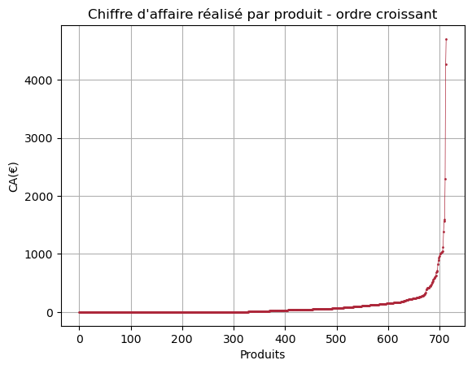

```python
fig = plt.figure()
ax = fig.add_subplot()
y =  ca_par_produit.sort_values(by="ca_par_produit(€)", ascending = True)["ca_par_produit(€)"].tolist()
ax.plot(y, "o-", color='#ad283b',  linewidth = 0.5, markersize=1)
ax.set_title("Chiffre d'affaire réalisé par produit - ordre croissant")
ax.set_xlabel("Produits")
ax.set_ylabel("CA(€)")
ax.grid(True)
plt.show()
```

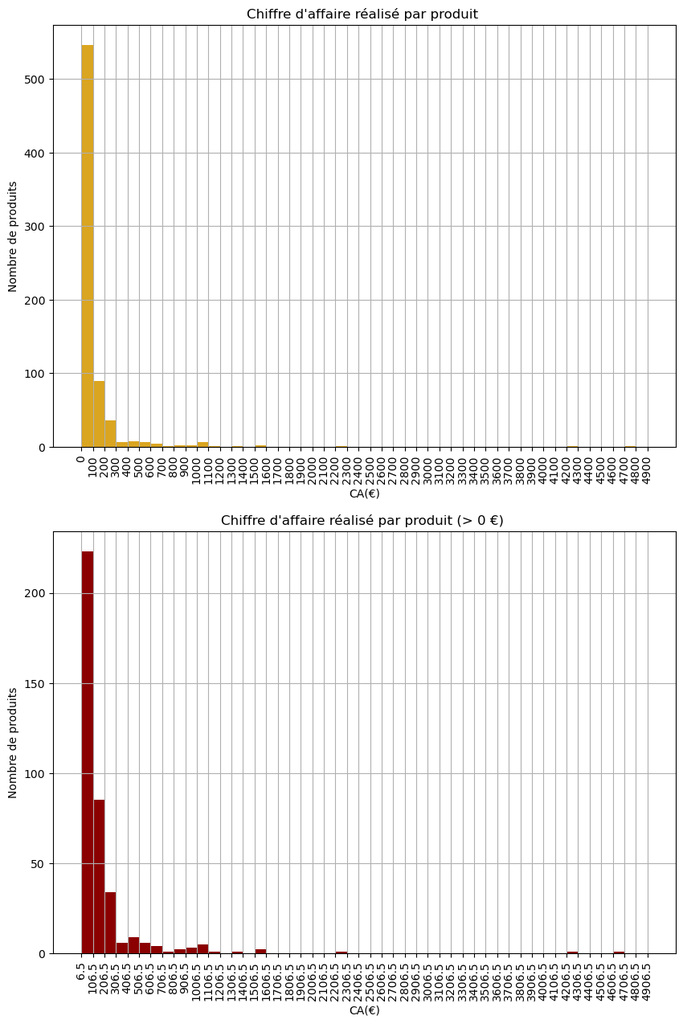

```python
fig = plt.figure(figsize = (10,15))
ax1 = fig.add_subplot(2,1,1)
ax2 = fig.add_subplot(2,1,2)
ax1.hist(ca_par_produit["ca_par_produit(€)"], bins = np.arange(ca_par_produit["ca_par_produit(€)"].min(),5000,100), color = "goldenrod")
ax1.set_title("Chiffre d'affaire réalisé par produit ")
ax1.set_ylabel("Nombre de produits")
ax1.set_xlabel("CA(€)")
tick_positions = np.arange(0,5000,100)
ax1.set_xticks(tick_positions)
ax1.set_xticklabels(tick_positions, rotation = 90)
ax1.grid(True)

ax2.hist(ca_par_produit[ca_par_produit["ca_par_produit(€)"]>0]["ca_par_produit(€)"], bins = np.arange(ca_par_produit[ca_par_produit["ca_par_produit(€)"]>0]["ca_par_produit(€)"].min(),5000,100), color = "darkred")
ax2.set_title("Chiffre d'affaire réalisé par produit (> 0 €) ")
ax2.set_ylabel("Nombre de produits")
ax2.set_xlabel("CA(€)")
tick_positions = np.arange(ca_par_produit[ca_par_produit["ca_par_produit(€)"]>0]["ca_par_produit(€)"].min(),5000,100)
ax2.set_xticks(tick_positions)
ax2.set_xticklabels(tick_positions, rotation = 90)
ax2.grid(True)

plt.show()
```

```python
# 329 produits vendus en ligne n'ont généré aucun CA, soit 46% des produits
ca_par_produit[ca_par_produit["pourcentage_du_ca"] == 0].shape
```

```
(329, 8)
```

```python
effectif_cumulé = ca_par_produit.sort_values(by="ca_par_produit(€)", ascending = False)["ca_par_produit(€)"].cumsum()
```

```python
effectif_cumulé
```

```
195     4704.0
72      8967.0
219    11255.0
71     12845.0
70     14405.0
        ...
395    70568.6
64     70568.6
65     70568.6
66     70568.6
713    70568.6
Name: ca_par_produit(€), Length: 714, dtype: float64
```

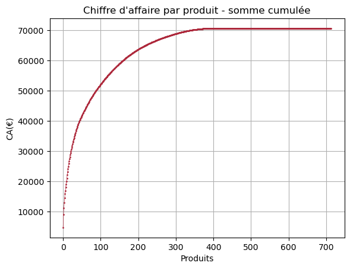

```python
fig = plt.figure()
ax = fig.add_subplot()
y = effectif_cumulé.to_list()
ax.plot(y, "o-", color='#ad283b',  linewidth = 0.5, markersize=1)
ax.set_title("Chiffre d'affaire par produit - somme cumulée")
ax.set_xlabel("Produits")
ax.set_ylabel("CA(€)")
ax.grid(True)

plt.show()
```

```python
#création des colonnes ca normalisé et du pourcentage du ca cumulé (pareto)
ca_par_produit_sorted =  ca_par_produit.sort_values(by="ca_par_produit(€)", ascending = False, ignore_index=True )
ca_par_produit_sorted['pareto'] = 100 *ca_par_produit_sorted["ca_par_produit(€)"].cumsum() / ca_par_produit_sorted["ca_par_produit(€)"].sum()
ca_par_produit_sorted['ca_normalise'] = (ca_par_produit_sorted["ca_par_produit(€)"] / ca_par_produit_sorted["ca_par_produit(€)"].max())*100
```

```python
ca_par_produit_sorted
```

|  | sku | product_id | post_name | total_sales | sales_frequency(%) | price | ca_par_produit(€) | pourcentage_du_ca | pareto | ca_normalise |
| --- | --- | --- | --- | --- | --- | --- | --- | --- | --- | --- |
| 0 | 7818 | 4334 | champagne-gosset-grand-blanc-de-blanc | 96 | 3.350785 | 49.0 | 4704.0 | 6.665854 | 6.665854 | 100.000000 |
| 1 | 1662 | 4144 | champagne-gosset-grand-rose | 87 | 3.036649 | 49.0 | 4263.0 | 6.040930 | 12.706785 | 90.625000 |
| 2 | 3510 | 4402 | cognac-frapin-vip-xo | 13 | 0.453752 | 176.0 | 2288.0 | 3.242235 | 15.949020 | 48.639456 |
| 3 | 11641 | 4142 | champagne-gosset-grand-millesime-2006 | 30 | 1.047120 | 53.0 | 1590.0 | 2.253127 | 18.202147 | 33.801020 |
| 4 | 304 | 4141 | gosset-champagne-grande-reserve | 40 | 1.396161 | 39.0 | 1560.0 | 2.210615 | 20.412761 | 33.163265 |
| ... | ... | ... | ... | ... | ... | ... | ... | ... | ... | ... |
| 709 | 16276 | 4924 | cave-de-castelmaure-corbieres-rouge-grande-cuv... | 0 | 0.000000 | 12.8 | 0.0 | 0.000000 | 100.000000 | 0.000000 |
| 710 | 15382 | 4115 | zind-humbrecht-riesling-gc-rangen-thann-clos-s... | 0 | 0.000000 | 100.0 | 0.0 | 0.000000 | 100.000000 | 0.000000 |
| 711 | 15339 | 4130 | zind-humbrecht-pinot-gris-roche-calcaire-2017 | 0 | 0.000000 | 23.0 | 0.0 | 0.000000 | 100.000000 | 0.000000 |
| 712 | 11668 | 4132 | zind-humbrecht-pinot-gris-grand-cru-rangen-de-... | 0 | 0.000000 | 88.4 | 0.0 | 0.000000 | 100.000000 | 0.000000 |
| 713 | 16230 | 7338 | domaine-saint-nicolas-fiefs-vendeens-blanc-les... | 0 | 0.000000 | 16.3 | 0.0 | 0.000000 | 100.000000 | 0.000000 |

714 rows × 10 columns

```
80 % du CA est généré par 18% des produits
50 % du CA est généré par 5% des produits
```

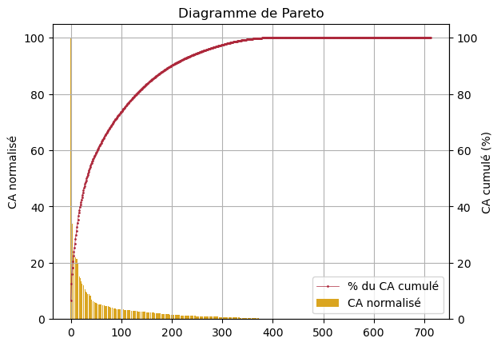

```python
print("80 % du CA est généré par 18% des produits ")
print("50 % du CA est généré par 5% des produits ")

fig = plt.figure()
ax = fig.add_subplot()
ax.bar(ca_par_produit_sorted.index, ca_par_produit_sorted["ca_normalise"], color="goldenrod", label = "CA normalisé")
ax.plot(ca_par_produit_sorted["pareto"], "o-", color='#ad283b',  linewidth = 0.5, markersize=1, label = "% du CA cumulé")
ax.set_title("Diagramme de Pareto")
ax.set_ylabel("CA normalisé")
secax = ax.secondary_yaxis("right")
secax.set_ylabel('CA cumulé (%)')
ax.grid(True)
plt.legend()
plt.show()
```

**2.2 Chiffre d'affaire réalisé en ligne**

```python
ca_réalisé_en_ligne = ca_par_produit["ca_par_produit(€)"].sum()
print(f'Chiffre d\'affaire réalisé en ligne: {ca_réalisé_en_ligne} €')
```

```
Chiffre d'affaire réalisé en ligne: 70568.6 €
```

**III . Prix : identification des outliers**

**3.1 Identification**

### Etude de la distribution des prix sur les références vendues en ligne et sur l'ensemble des références

Références vendues en ligne

```python
ca_par_produit.sort_values(by="price", ascending = False ).head()
```

|  | sku | product_id | post_name | total_sales | sales_frequency(%) | price | ca_par_produit(€) | pourcentage_du_ca |
| --- | --- | --- | --- | --- | --- | --- | --- | --- |
| 200 | 15940 | 4352 | champagne-egly-ouriet-grand-cru-millesime-2008 | 5 | 0.174520 | 225.0 | 1125.0 | 1.594193 |
| 426 | 14581 | 5001 | david-duband-charmes-chambertin-grand-cru-2014 | 0 | 0.000000 | 217.5 | 0.0 | 0.000000 |
| 587 | 14983 | 5892 | coteaux-champenois-egly-ouriet-ambonnay-rouge-... | 3 | 0.104712 | 191.3 | 573.9 | 0.813251 |
| 219 | 3510 | 4402 | cognac-frapin-vip-xo | 13 | 0.453752 | 176.0 | 2288.0 | 3.242235 |
| 553 | 15185 | 5767 | camille-giroud-clos-de-vougeot-2016 | 0 | 0.000000 | 175.0 | 0.0 | 0.000000 |

```python
ca_par_produit.sort_values(by="price", ascending = True ).head()
```

|  | sku | product_id | post_name | total_sales | sales_frequency(%) | price | ca_par_produit(€) | pourcentage_du_ca |
| --- | --- | --- | --- | --- | --- | --- | --- | --- |
| 645 | 14570 | 6129 | moulin-de-gassac-igp-pays-dherault-guilhem-bla... | 0 | 0.000000 | 5.2 | 0.0 | 0.000000 |
| 98 | 16210 | 4172 | maurel-pays-oc-chardonnay-2019 | 43 | 1.500873 | 5.7 | 245.1 | 0.347322 |
| 99 | 16211 | 4173 | maurel-pays-doc-chenin-colombard-2019 | 13 | 0.453752 | 5.7 | 74.1 | 0.105004 |
| 560 | 14338 | 5777 | maurel-pays-d-oc-cabernet-sauvignon-2017 | 0 | 0.000000 | 5.7 | 0.0 | 0.000000 |
| 100 | 16209 | 4174 | maurel-cabardes-tradition-2017 | 6 | 0.209424 | 5.7 | 34.2 | 0.048463 |

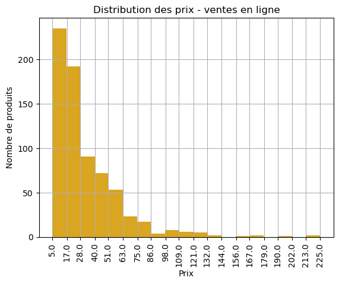

```python
fig = plt.figure()
ax = fig.add_subplot()
ax.hist(ca_par_produit["price"],bins = np.linspace(ca_par_produit["price"].min(),ca_par_produit["price"].max(),20), color = "goldenrod")
ax.set_title("Distribution des prix - ventes en ligne")
ax.set_ylabel("Nombre de produits")
tick_positions = np.around(np.linspace(ca_par_produit["price"].min(),ca_par_produit["price"].max(),20))
ax.set_xticks(tick_positions)
ax.set_xticklabels(tick_positions, rotation = 90)
ax.set_xlabel("Prix")
plt.grid(True)
plt.show()
```

Ensemble des références

```python
erp.sort_values(by="price", ascending = False ).head()
```

|  | product_id | onsale_web | price | stock_quantity | stock_status |
| --- | --- | --- | --- | --- | --- |
| 208 | 4352 | 1 | 225.0 | 0 | outofstock |
| 460 | 5001 | 1 | 217.5 | 20 | instock |
| 635 | 5892 | 1 | 191.3 | 10 | instock |
| 227 | 4402 | 1 | 176.0 | 8 | instock |
| 598 | 5767 | 1 | 175.0 | 12 | instock |

```python
erp.sort_values(by="price", ascending = True ).head()
```

|  | product_id | onsale_web | price | stock_quantity | stock_status |
| --- | --- | --- | --- | --- | --- |
| 700 | 6129 | 1 | 5.2 | 30 | instock |
| 100 | 4172 | 1 | 5.7 | 167 | instock |
| 101 | 4173 | 1 | 5.7 | 100 | instock |
| 102 | 4174 | 1 | 5.7 | 94 | instock |
| 605 | 5777 | 1 | 5.7 | 132 | instock |

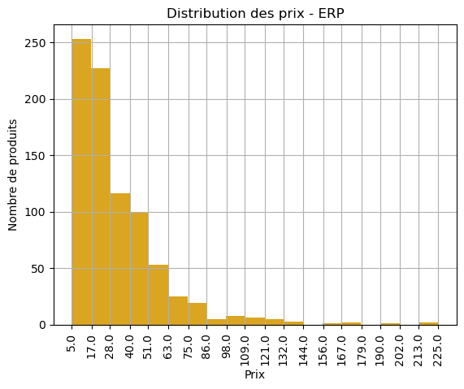

```python
fig = plt.figure()
ax = fig.add_subplot()
ax.hist(erp["price"],bins = np.linspace(erp["price"].min(),erp["price"].max(),20), color = "goldenrod")
ax.set_title("Distribution des prix - ERP")
ax.set_ylabel("Nombre de produits")
tick_positions = np.around(np.linspace(erp["price"].min(),erp["price"].max(),20))
ax.set_xticks(tick_positions)
ax.set_xticklabels(tick_positions, rotation = 90)
ax.set_xlabel("Prix")
plt.grid(True)
plt.show()
```

### Moyenne, mediane, quartiles, min, max

Références vendues en ligne

```python
ca_par_produit["price"].describe()
```

```
count    714.000000
mean      32.493137
std       27.810525
min        5.200000
25%       14.100000
50%       23.550000
75%       42.175000
max      225.000000
Name: price, dtype: float64
```

Ensemble des références

```python
erp["price"].describe()
```

```
count    825.000000
mean      32.415636
std       26.795849
min        5.200000
25%       14.600000
50%       24.400000
75%       42.000000
max      225.000000
Name: price, dtype: float64
```

### Mesure de forme

Références vendues en ligne

```python
print("skw:\n",ca_par_produit["price"].skew())
# comme le montre l'histogramme, la distribution des prix est étalée à droite, avec un skew >0
```

```
skw:
 2.5809012630033705
```

Ensemble des références

```python
print("skw:\n",erp["price"].skew())
```

```
skw:
 2.6227973685638717
```

### Coefficient de variation

Références vendues en ligne

```python
coefficient_variation = ca_par_produit["price"].std()/ca_par_produit["price"].mean()*100
print(f"coefficient de variation : {round(coefficient_variation,2)} %")
#grande dispersion autour de la moyenne
```

```
coefficient de variation : 85.59 %
```

Ensemble des références

```python
coefficient_variation = erp["price"].std()/erp["price"].mean()*100
print(f"coefficient de variation : {round(coefficient_variation,2)} %")
#grande dispersion autour de la moyenne
```

```
coefficient de variation : 82.66 %
```

### IQR, whiskers, outliers : méthode boxplotstats, méthode IQR, méthode Z score

#### méthode boxplotstats

Références vendues en ligne

```python
boxplotstats = cbk.boxplot_stats(ca_par_produit["price"])
boxplotstats
```

```
[{'mean': 32.49313725490196,
  'iqr': 28.075000000000003,
  'cilo': 21.90043166453619,
  'cihi': 25.199568335463812,
  'whishi': 83.7,
  'whislo': 5.2,
  'fliers': array([100. ,  88.4, 225. , 126.5,  85.6, 176. , 108.5, 157. , 104. ,
         109.6, 102.3, 137. , 217.5, 105. , 105. , 112. ,  86.8,  92. ,
         124.8, 175. , 191.3,  93. , 122. , 114. , 135. , 105.6, 116.4,
         115. , 121. ,  99. , 115. , 121. ]),
  'q1': 14.1,
  'med': 23.55,
  'q3': 42.175000000000004}]
```

```python
print(f"Nombre d'outliers détectés, méthode boxplot stats = {len(boxplotstats[0]['fliers'])}")
```

```
Nombre d'outliers détectés, méthode boxplot stats = 32
```

Ensemble des références

```python
boxplotstats_erp = cbk.boxplot_stats(erp["price"])
boxplotstats_erp
```

```
[{'mean': 32.41563636363637,
  'iqr': 27.4,
  'cilo': 22.902305479219557,
  'cihi': 25.89769452078044,
  'whishi': 83.0,
  'whislo': 5.2,
  'fliers': array([ 86.1, 100. ,  88.4, 225. , 126.5,  85.6, 176. , 108.5, 157. ,
         104. , 109.6, 144. , 102.3, 137. , 217.5, 105. , 105. , 112. ,
          86.8,  84.7,  92. ,  83.7, 124.8, 175. , 191.3,  93. , 122. ,
         114. , 135. , 105.6, 116.4, 115. , 121. ,  99. , 115. , 121. ,
          92. ]),
  'q1': 14.6,
  'med': 24.4,
  'q3': 42.0}]
```

```python
print(f"Nombre d'outliers détectés ERP, méthode boxplot stats = {len(boxplotstats_erp[0]['fliers'])}")
```

```
Nombre d'outliers détectés ERP, méthode boxplot stats = 37
```

#### méthode IQR

Références vendues en ligne

```python
Q1 = ca_par_produit["price"].quantile(0.25)
Q3 = ca_par_produit["price"].quantile(0.75)
IQ = Q3-Q1
```

```python
print(f"IQR = {IQ}")
```

```
IQR = 28.075000000000003
```

```python
left_whisker = Q1-1.5*IQ
right_whisker = Q3+1.5*IQ
```

```python
print(f"left_whisker =  {left_whisker}")
print(f"right_whisker = {right_whisker}")
```

```
left_whisker =  -28.012500000000003
right_whisker = 84.28750000000001
```

```python
liste_outliers_méthode_IQR = ca_par_produit[(ca_par_produit["price"]<left_whisker) | (ca_par_produit["price"]>right_whisker)]["price"]
```

```python
print(f"Nombre d'outliers détectés, méthode IQR = {len(liste_outliers_méthode_IQR)}")
```

```
Nombre d'outliers détectés, méthode IQR = 32
```

Ensemble des références

```python
Q1_ERP = erp["price"].quantile(0.25)
Q3_ERP = erp["price"].quantile(0.75)
IQ_ERP = Q3_ERP-Q1_ERP
```

```python
print(f"IQR = {IQ_ERP}")
```

```
IQR = 27.4
```

```python
left_whisker_ERP = Q1_ERP-1.5*IQ_ERP
right_whisker_ERP = Q3_ERP+1.5*IQ_ERP
```

```python
print(f"left_whisker =  {left_whisker_ERP}")
print(f"right_whisker = {right_whisker_ERP}")
```

```
left_whisker =  -26.499999999999993
right_whisker = 83.1
```

```python
liste_outliers_méthode_IQR_ERP = erp[(erp["price"]<left_whisker_ERP) | (erp["price"]>right_whisker_ERP)]["price"]
```

```python
print(f"Nombre d'outliers détectés, méthode IQR = {len(liste_outliers_méthode_IQR_ERP)}")
```

```
Nombre d'outliers détectés, méthode IQR = 37
```

#### méthode z-score

Références vendues en ligne

```python
mean =  ca_par_produit["price"].mean()
```

```python
std = ca_par_produit["price"].std()
```

```python
liste_outliers_méthode_zscore = []
for price in ca_par_produit["price"] :
    if abs((price-mean)/std)>2 :
        liste_outliers_méthode_zscore.append(price)
```

```python
print(f"Nombre d'outliers détectés, méthode IQR = {len(liste_outliers_méthode_zscore)}")
```

```
Nombre d'outliers détectés, méthode IQR = 30
```

Ensemble des références

```python
mean_erp =  erp["price"].mean()
```

```python
std_erp = erp["price"].std()
```

```python
liste_outliers_méthode_zscore_ERP = []
for price in erp["price"] :
    if abs((price-mean_erp)/std_erp)>2 :
        liste_outliers_méthode_zscore_ERP.append(price)
```

```python
print(f"Nombre d'outliers détectés, méthode IQR = {len(liste_outliers_méthode_zscore_ERP)}")
```

```
Nombre d'outliers détectés, méthode IQR = 34
```

### Liste des outliers

Références vendues en ligne

```python
df_outliers = ca_par_produit[(ca_par_produit["price"]<boxplotstats[0]["whislo"]) | (ca_par_produit["price"]>boxplotstats[0]["whishi"])].sort_values(by = "price", ascending = False)
df_outliers
```

|  | sku | product_id | post_name | total_sales | sales_frequency(%) | price | ca_par_produit(€) | pourcentage_du_ca |
| --- | --- | --- | --- | --- | --- | --- | --- | --- |
| 200 | 15940 | 4352 | champagne-egly-ouriet-grand-cru-millesime-2008 | 5 | 0.174520 | 225.0 | 1125.0 | 1.594193 |
| 426 | 14581 | 5001 | david-duband-charmes-chambertin-grand-cru-2014 | 0 | 0.000000 | 217.5 | 0.0 | 0.000000 |
| 587 | 14983 | 5892 | coteaux-champenois-egly-ouriet-ambonnay-rouge-... | 3 | 0.104712 | 191.3 | 573.9 | 0.813251 |
| 219 | 3510 | 4402 | cognac-frapin-vip-xo | 13 | 0.453752 | 176.0 | 2288.0 | 3.242235 |
| 553 | 15185 | 5767 | camille-giroud-clos-de-vougeot-2016 | 0 | 0.000000 | 175.0 | 0.0 | 0.000000 |
| 222 | 7819 | 4406 | cognac-frapin-chateau-de-fontpinot-1989-20-ans | 0 | 0.000000 | 157.0 | 0.0 | 0.000000 |
| 382 | 14220 | 4904 | domaine-des-croix-corton-charlemagne-grand-cru... | 5 | 0.174520 | 137.0 | 685.0 | 0.970687 |
| 642 | 14923 | 6126 | champagne-gosset-celebris-vintage-2007 | 2 | 0.069808 | 135.0 | 270.0 | 0.382606 |
| 202 | 12589 | 4355 | champagne-egly-ouriet-grand-cru-brut-blanc-de-... | 11 | 0.383944 | 126.5 | 1391.5 | 1.971840 |
| 511 | 14915 | 5612 | domaine-weinbach-gewurztraminer-gc-furstentum-... | 0 | 0.000000 | 124.8 | 0.0 | 0.000000 |
| 603 | 14775 | 5917 | wemyss-malts-single-cask-scotch-whisky-choc-n-... | 0 | 0.000000 | 122.0 | 0.0 | 0.000000 |
| 654 | 15072 | 6213 | domaine-des-comtes-lafon-volnay-1er-cru-santen... | 0 | 0.000000 | 121.0 | 0.0 | 0.000000 |
| 657 | 15070 | 6216 | domaine-des-comtes-lafon-volnay-1er-cru-champa... | 0 | 0.000000 | 121.0 | 0.0 | 0.000000 |
| 648 | 15126 | 6202 | domaine-clerget-echezeaux-en-orveaux-2015 | 0 | 0.000000 | 116.4 | 0.0 | 0.000000 |
| 653 | 13996 | 6212 | domaine-des-comtes-lafon-volnay-1er-cru-santen... | 2 | 0.069808 | 115.0 | 230.0 | 0.325924 |
| 656 | 12790 | 6215 | domaine-des-comtes-lafon-volnay-1er-cru-champa... | 0 | 0.000000 | 115.0 | 0.0 | 0.000000 |
| 604 | 14773 | 5918 | wemyss-malts-single-cask-scotch-whisky-chai-ca... | 0 | 0.000000 | 114.0 | 0.0 | 0.000000 |
| 437 | 13914 | 5025 | champagne-agrapart-fils-lavizoise-grand-cru-20... | 0 | 0.000000 | 112.0 | 0.0 | 0.000000 |
| 228 | 12857 | 4582 | chateau-de-puligny-montrachet-1cru-champ-canet... | 0 | 0.000000 | 109.6 | 0.0 | 0.000000 |
| 220 | 3507 | 4404 | cognac-frapin-fontpinot-xo | 2 | 0.069808 | 108.5 | 217.0 | 0.307502 |
| 647 | 14596 | 6201 | david-duband-chambolle-musigny-1er-cru-les-sen... | 0 | 0.000000 | 105.6 | 0.0 | 0.000000 |
| 431 | 12791 | 5007 | domaine-des-comtes-lafon-volnay-1er-cru-santen... | 0 | 0.000000 | 105.0 | 0.0 | 0.000000 |
| 432 | 11602 | 5008 | domaine-des-comtes-lafon-volnay-1er-cru-santen... | 0 | 0.000000 | 105.0 | 0.0 | 0.000000 |
| 223 | 3509 | 4407 | cognac-frapin-cigar-blend | 1 | 0.034904 | 104.0 | 104.0 | 0.147374 |
| 381 | 14805 | 4903 | domaine-des-croix-corton-grand-cru-les-greves-... | 0 | 0.000000 | 102.3 | 0.0 | 0.000000 |
| 64 | 15382 | 4115 | zind-humbrecht-riesling-gc-rangen-thann-clos-s... | 0 | 0.000000 | 100.0 | 0.0 | 0.000000 |
| 655 | 11601 | 6214 | domaine-des-comtes-lafon-volnay-1er-cru-champa... | 0 | 0.000000 | 99.0 | 0.0 | 0.000000 |
| 602 | 14774 | 5916 | wemyss-malts-single-cask-chocolate-moka-cake | 0 | 0.000000 | 93.0 | 0.0 | 0.000000 |
| 502 | 19822 | 5565 | tempier-bandol-cabassaou-2017 | 0 | 0.000000 | 92.0 | 0.0 | 0.000000 |
| 66 | 11668 | 4132 | zind-humbrecht-pinot-gris-grand-cru-rangen-de-... | 0 | 0.000000 | 88.4 | 0.0 | 0.000000 |
| 438 | 13913 | 5026 | champagne-agrapart-fils-mineral-extra-brut-bla... | 0 | 0.000000 | 86.8 | 0.0 | 0.000000 |
| 206 | 13853 | 4359 | champagne-larmandier-bernier-grand-cru-vieille... | 1 | 0.034904 | 85.6 | 85.6 | 0.121300 |

```python
df_outliers.shape
```

```
(32, 8)
```

Ensemble des références

```python
df_outliers_ERP = erp[(erp["price"]<boxplotstats_erp[0]["whislo"]) | (erp["price"]>boxplotstats_erp[0]["whishi"])].sort_values(by = "price", ascending = False)
df_outliers_ERP
```

|  | product_id | onsale_web | price | stock_quantity | stock_status |
| --- | --- | --- | --- | --- | --- |
| 208 | 4352 | 1 | 225.0 | 0 | outofstock |
| 460 | 5001 | 1 | 217.5 | 20 | instock |
| 635 | 5892 | 1 | 191.3 | 10 | instock |
| 227 | 4402 | 1 | 176.0 | 8 | instock |
| 598 | 5767 | 1 | 175.0 | 12 | instock |
| 230 | 4406 | 1 | 157.0 | 3 | instock |
| 242 | 4594 | 1 | 144.0 | 0 | outofstock |
| 411 | 4904 | 1 | 137.0 | 13 | instock |
| 697 | 6126 | 1 | 135.0 | 10 | instock |
| 210 | 4355 | 1 | 126.5 | 2 | instock |
| 556 | 5612 | 1 | 124.8 | 12 | instock |
| 651 | 5917 | 1 | 122.0 | 4 | instock |
| 712 | 6216 | 1 | 121.0 | 6 | instock |
| 709 | 6213 | 1 | 121.0 | 7 | instock |
| 703 | 6202 | 1 | 116.4 | 14 | instock |
| 711 | 6215 | 1 | 115.0 | 4 | instock |
| 708 | 6212 | 1 | 115.0 | 2 | instock |
| 652 | 5918 | 1 | 114.0 | 8 | instock |
| 475 | 5025 | 1 | 112.0 | 0 | outofstock |
| 240 | 4582 | 1 | 109.6 | 7 | instock |
| 228 | 4404 | 1 | 108.5 | 2 | instock |
| 702 | 6201 | 1 | 105.6 | 7 | instock |
| 466 | 5008 | 1 | 105.0 | 10 | instock |
| 465 | 5007 | 1 | 105.0 | 17 | instock |
| 231 | 4407 | 1 | 104.0 | 6 | instock |
| 410 | 4903 | 1 | 102.3 | 20 | instock |
| 66 | 4115 | 1 | 100.0 | 11 | instock |
| 710 | 6214 | 1 | 99.0 | 7 | instock |
| 650 | 5916 | 1 | 93.0 | 3 | instock |
| 545 | 5565 | 1 | 92.0 | 0 | outofstock |
| 724 | 6324 | 0 | 92.0 | 18 | instock |
| 68 | 4132 | 1 | 88.4 | 5 | instock |
| 476 | 5026 | 1 | 86.8 | 2 | instock |
| 19 | 4055 | 0 | 86.1 | 0 | outofstock |
| 214 | 4359 | 1 | 85.6 | 0 | outofstock |
| 486 | 5070 | 1 | 84.7 | 0 | outofstock |
| 551 | 5580 | 1 | 83.7 | 18 | instock |

```python
df_outliers_ERP.shape
```

```
(37, 5)
```

```python
outliers_suplementaires_ERP =set(df_outliers_ERP["product_id"].tolist())-set(df_outliers["product_id"].tolist())
outliers_suplementaires_ERP
```

```
{4055, 4594, 5070, 5580, 6324}
```

**3.2 Représentation graphique**

### Boxplot

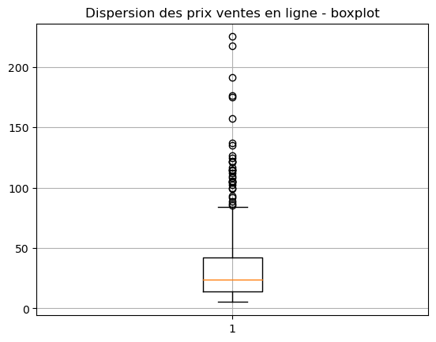

```python
fig = plt.figure()
ax = fig.add_subplot()
ax.boxplot(ca_par_produit["price"])
ax.set_title("Dispersion des prix ventes en ligne - boxplot")
plt.grid(True)
plt.show()
```

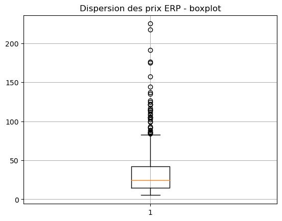

```python
fig = plt.figure()
ax = fig.add_subplot()
ax.boxplot(erp["price"])
ax.set_title("Dispersion des prix ERP - boxplot")
plt.grid(True)
plt.show()
```

### Scatterplot

```python
df_valeurs_ok = ca_par_produit[(ca_par_produit["price"]>=boxplotstats[0]["whislo"]) & (ca_par_produit["price"]<=boxplotstats[0]["whishi"])]
df_valeurs_ok.shape
```

```
(682, 8)
```

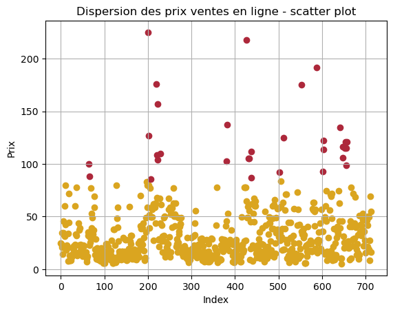

```python
fig = plt.figure()
ax = fig.add_subplot()
ax.scatter(df_valeurs_ok["price"].index, df_valeurs_ok["price"], color = "goldenrod")
ax.scatter(df_outliers["price"].index, df_outliers["price"],  color='#ad283b')
ax.set_title("Dispersion des prix ventes en ligne - scatter plot")
ax.set_ylabel("Prix")
ax.set_xlabel("Index")
plt.grid(True)
plt.show()
```

```python
df_valeurs_ok_ERP = erp[(erp["price"]>=boxplotstats_erp[0]["whislo"]) & (erp["price"]<=boxplotstats_erp[0]["whishi"])]
df_valeurs_ok_ERP.shape
```

```
(788, 5)
```

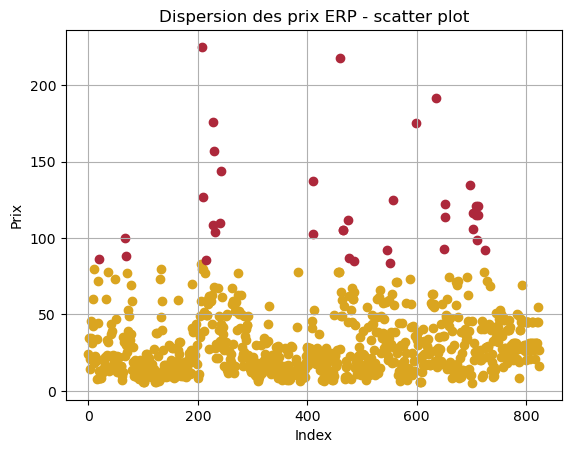

```python
fig = plt.figure()
ax = fig.add_subplot()
ax.scatter(df_valeurs_ok_ERP["price"].index, df_valeurs_ok_ERP["price"], color = "goldenrod")
ax.scatter(df_outliers_ERP["price"].index, df_outliers_ERP["price"],  color='#ad283b')
ax.set_title("Dispersion des prix ERP - scatter plot")
ax.set_ylabel("Prix")
ax.set_xlabel("Index")
plt.grid(True)
plt.show()
```

**IV . Conclusion**

### Pricipaux éléments d'analyse

**Best sellers :**  
**- 50% du CA réalisé en ligne est généré par 5 % des produits**  
**- 80% du CA réalisé en ligne est généré par 18 % des produits**

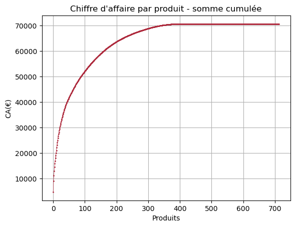

```python
fig = plt.figure()
ax = fig.add_subplot()
y = effectif_cumulé.to_list()
ax.plot(y, "o-", color='#ad283b',  linewidth = 0.5, markersize=1)
ax.set_title("Chiffre d'affaire par produit - somme cumulée")
ax.set_xlabel("Produits")
ax.set_ylabel("CA(€)")
ax.grid(True)
plt.show()
```

**- 46% des produits vendus en ligne n'ont généré aun CA sur la période considérée**

```python
ca_par_produit[ca_par_produit["pourcentage_du_ca"] == 0].shape
```

```
(329, 8)
```

**- Aucune valeur aberrante ou erreur n'a été repérée concernant les prix**

### Recommandations concernant le système d'information

**- Etudier les références non retrouvées entre liaison /web et erp /web e teffectuer les corrections**

```python
#id_web présents sur fichier liaison mais sku non retrouvés dans le fichier web
#corriger le fichier liaison
sku_fichier_liaison_non_retrouvés
```

```
{12601,
 13577,
 13771,
 14360,
 14377,
 14379,
 14648,
 '14680-1',
 14689,
 14715,
 14730,
 14785,
 15065,
 15154,
 15272,
 15529,
 15586,
 15608,
 15609,
 15630,
 nan}
```

```python
#717 articles vendus sur le web d'après l'ERP (df erp) vs 714 sku (df web), quels produits n'ont pas été retrouvés ?
#corriger le statut onsale_web dans l'ERP pour ces références
onsale_web_but_not_found_web
```

```
{4594, 5070, 5075}
```

**- Corriger l'erreur de statut du stock**

```python
# une erreur concernant le statut du stock
erp[(erp["stock_quantity"] == 0 )&(erp["stock_status"] == "instock")]
```

|  | product_id | onsale_web | price | stock_quantity | stock_status |
| --- | --- | --- | --- | --- | --- |
| 443 | 4954 | 1 | 25.0 | 0 | instock |

**- Etudier les fonctions non utilisées sur le web : notamment rating count, average rating**

**- Etudier la possibilité de mettre en place une solution centralisée**

### Recommandation concernant l'offre produit

**- Compléter l’analyse des produits par le CA réalisée par une analyse de la rentabilité et de l'âge des produits (50% du CA réalisé en ligne est généré par 5 % des produits, 46% des produits vendus en ligne n'ont généré aun CA sur la période considérée)**

Retour au sommaire